# The Complete Theme Guide

Edgar Zamora

2020-04-02

In creating visualizations, one aims not only to create a visualization that can convey the message behind the data but also to create a visualization that is appealing to the viewer. The `theme` function in ggplot allows for one to do so, but whenever I look at the reference page I sometimes become over whelmed by the number of components. For that reason, this post will focus on detailing non-data components of ones plot.

Let me say that the components below are not exhaustive, there may and probably are other components that have been created by the R community. These will not be covered in this post because of possibility of never being able to cover them all. Also I will not be covering complete themes like `theme_bw()`, `theme_minimal()`, or others because they already have predetermined components. If you would like to learn more about complete themes you can go to the [reference page](https://ggplot2.tidyverse.org/reference/ggtheme.html).

The primary package we will be working today is `ggplot2`, will load the metapackge `tidyverse` because of other pakcages that may come into play.

```r
library(tidyverse)
library(patchwork)
library(cowplot)

knitr::opts_chunk$set(fig.align = 'center')
```

# Components

When looking at the [reference page](https://ggplot2.tidyverse.org/reference/theme.html) for the `theme` function, there a total of 92 (if my counting was correct) arguments that can be used to customize a plot!! Though some are used more often than not, I thought it would be beneficial to myself and others to document what each individual argument does in respects to customizing a plot.

There are a few things to know when using the theme arguments.

1. All arguments need to reference some kind of element. There are six elements.
- `element_line()`: using this element will change anything that is considered a line within the plot
- `element_rect()`: changes rectangular aspects (borders and backgrounds) of plots
- `element_text()`: changes all text of a plot
- `element_blank()`: makes the specified element disappear/leaves it blank
- `element_render()`: not quite sure, but will update when I figure it out
- `element_grob()`: generates a grid grob from the theme
2. Arguments within the theme function should follow a general ordering.
- `plot.backgroud = element_rect()`
- `axis.text = element_text()`
- `legend.position = elemen_blank()`
- and many others.

Knowing these two aspects when using the `theme()` function will making modifying components of a plot quick and easy. Within each `element_*` there are additional aruegments like `size`, `colour`, `linetype` and more that will be need to pass the particular edits you would like to make to the plot. You can find a complete list of available arguments in the theme elements [reference page](https://ggplot2.tidyverse.org/reference/element.html).

To keep things consistent with the reference page for the `theme` function I will be using the same plot they have and build off that to detail all the customizations available. The dataset used to create the graphic is from the `mtcars` package which should be automatically installed when if you have the most current version of R and RStudio.

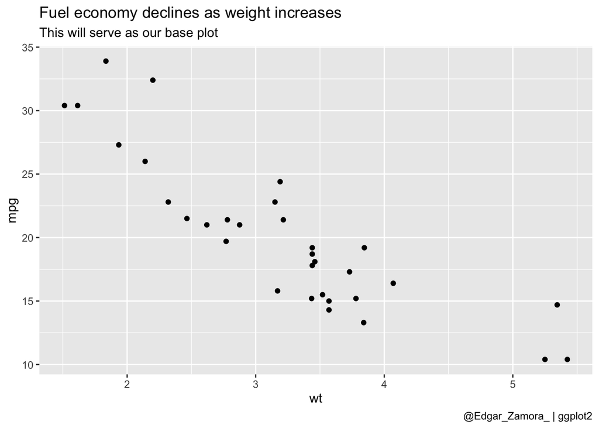

```r
base_plot <- ggplot(mtcars, aes(wt, mpg)) +
  geom_point() +
  labs(title = "Fuel economy declines as weight increases",
       subtitle = "This will serve as our base plot",
       caption = "@Edgar_Zamora_ | ggplot2")

base_plot
```

## Plot

### Background

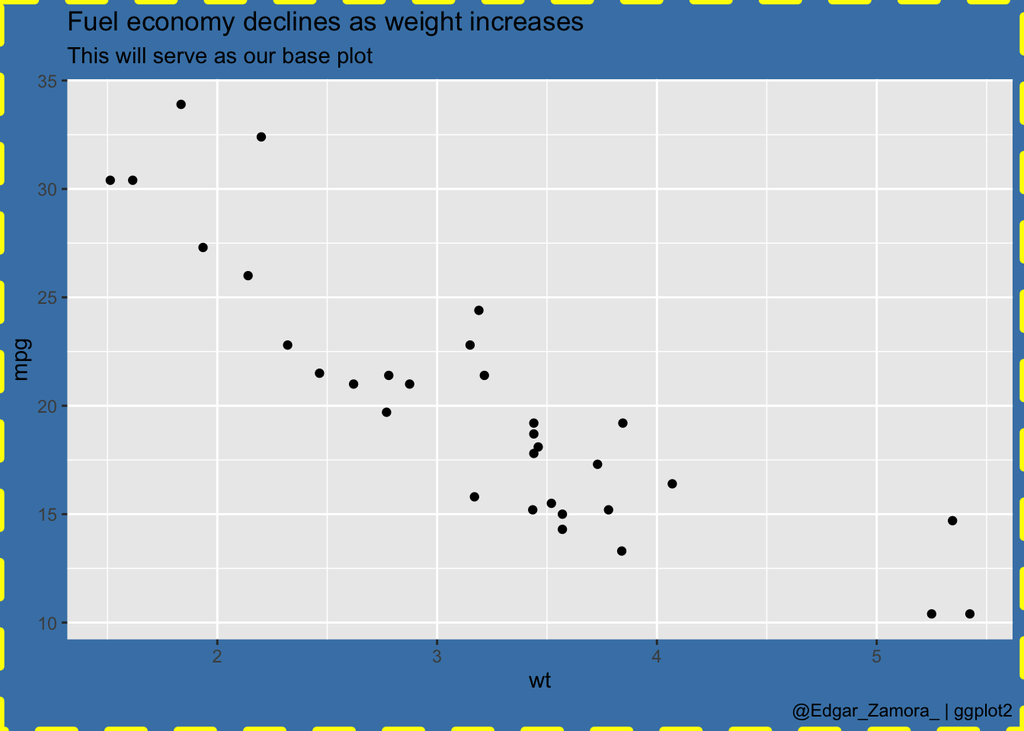

```r
base_plot +
  theme(plot.background = element_rect(fill = "steelblue", linetype = "dashed", colour = "yellow", size = 2))
```

### Title

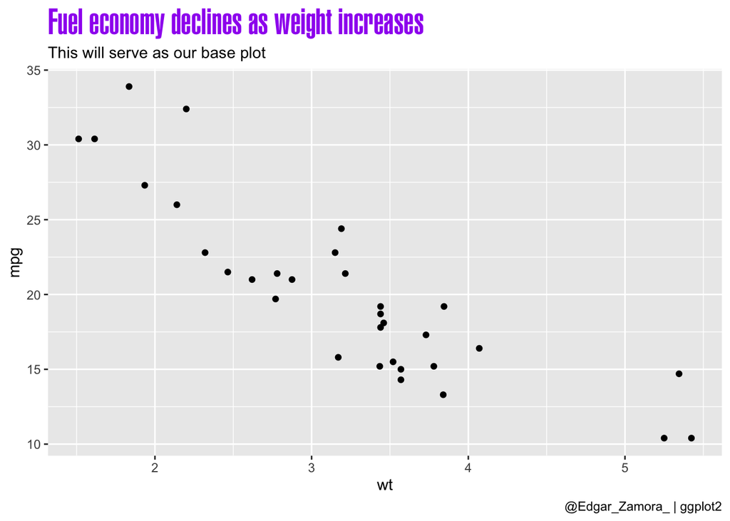

```r
base_plot +
  theme(plot.title = element_text(size = 25, face = "plain", colour = "purple", family = "Helvetica LT Ultra Compressed"))
```

### Title position

### Subtitle

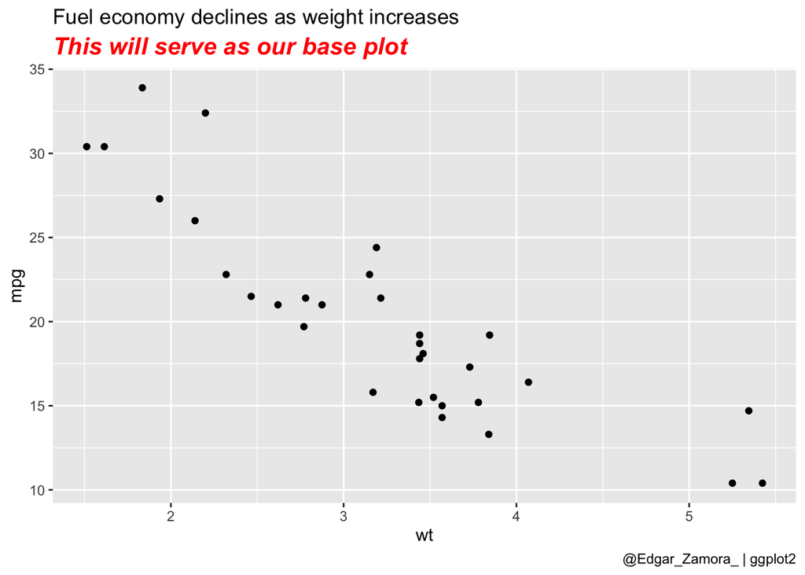

```r
base_plot +
  theme(plot.subtitle = element_text(size = 15, face = "bold.italic", colour = "red"))
```

### Capition

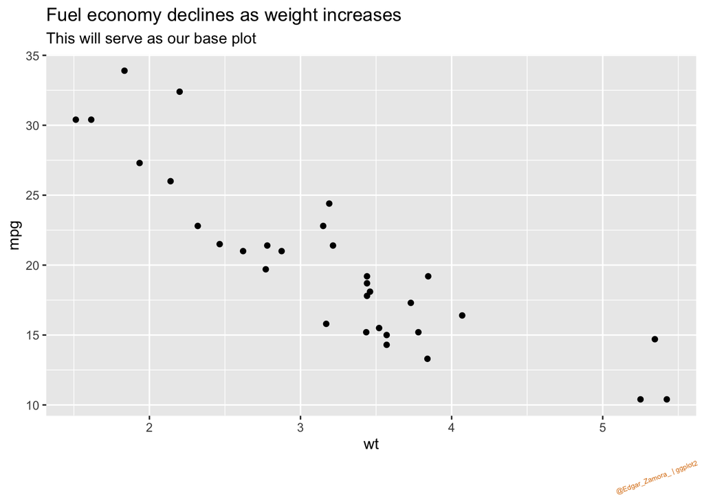

```r
base_plot +
  theme(plot.caption = element_text(size = 5, angle = 20, colour = "#DB7D11"))
```

### Caption position

### Tag

### Tag position

### Margin

There are number of different units you can use to move the margins. These are some of the most popular ones

1. Centimeters (**“cm”**)
2. Inches (**“in”**)
3. Millimeters (**"mm**)
4. Points (**“pt”**)

A complete list of possible units and their conversions can be found by going to the `unit()` function [reference page](https://www.rdocumentation.org/packages/grid/versions/3.6.2/topics/unit).

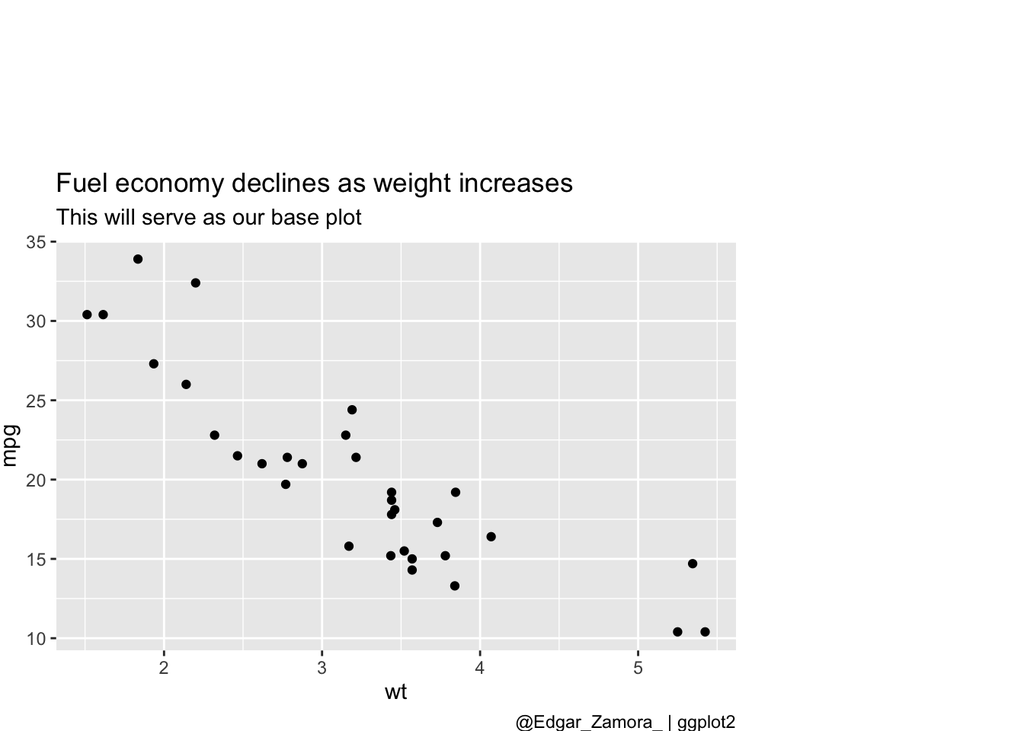

```r
base_plot +
  theme(plot.margin = margin(t = 3, r = 5, b = 0, l = 0, unit = "cm"))
```

## Facets

The following examples are applicable when you use `facet_grid()` or `facet_wrap()` in your plot. Specically whenever using a `strip_*` argument, it applies to the part above each individual plot. Keep in mind that edits to the strip arguement are inherated by all strips. I believe there are ways to edit each strip individually but you will have to do some research on how to do that because I have not done that before.

### Background

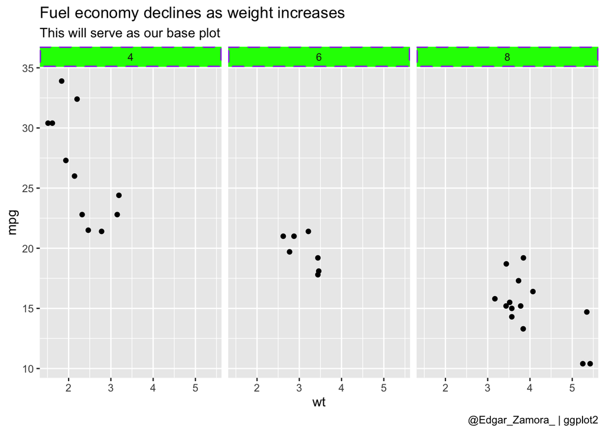

```r
base_plot +
  facet_grid(~cyl) +
  theme(strip.background = element_rect(colour = "purple", linetype = "dashed", size = 1, fill = "green"))
```

### Background (x-axis)

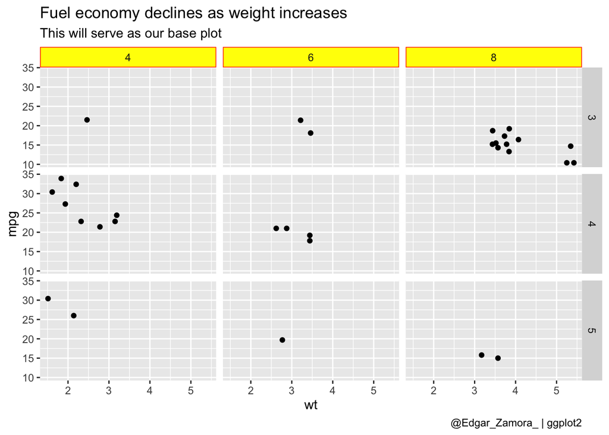

```r
base_plot +
  facet_grid(gear~cyl) +
  theme(strip.background.x = element_rect(colour = "red", fill = "yellow"))
```

### Background (y-axix)

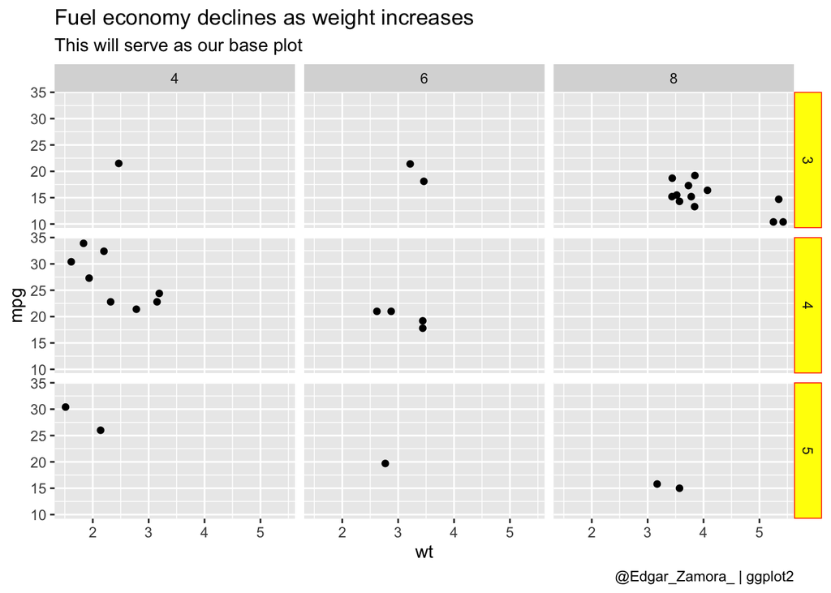

```r
base_plot +
  facet_grid(gear~cyl) +
  theme(strip.background.y = element_rect(colour = "red", fill = "yellow"))
```

### Placement

There are couple prerequistes that need to be included in your plot inorder for `strip_placement()` to work correctly. First, and probably most important is that your strip *must* share an axis with some label. In the example below you can see the strip shares the y-axis with the mpg scale. If the strip were placed at the top or to the left of the plot `strip.placment()` would be used optimally. The second requirement is that you use `facet_wrap()` instead of `facet_grid()`. Not sure what the particular reason is but if you use `facet_gride()` the `strip.placement()` will be ignored when rendering. The only argument that `strip.placement()` can take is a string that tells R to place the strip “inside” or “outside” of the plot. Below I provide examples of both.

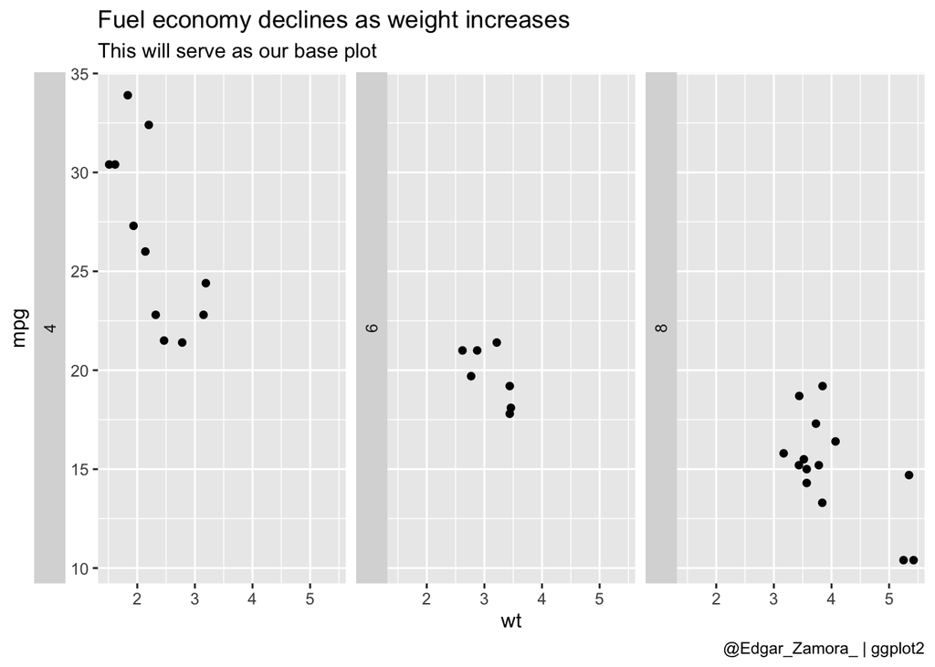

```r
base_plot +
  facet_wrap(~cyl, strip.position = "left") +
  theme(strip.placement = "outside")
```

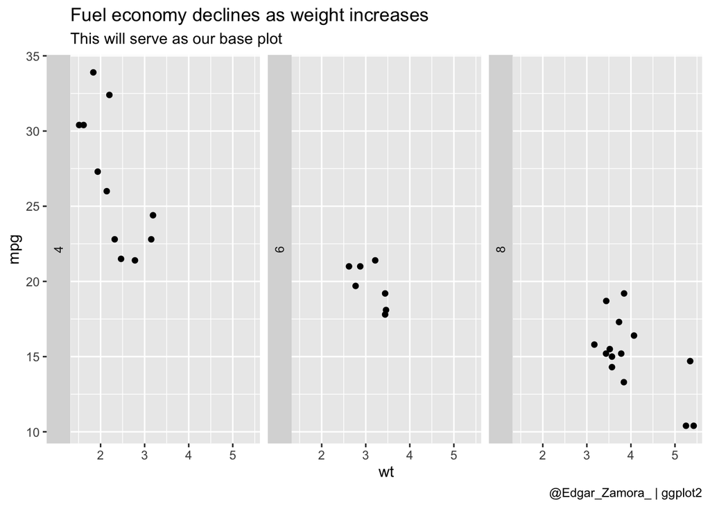

```r
base_plot +
  facet_wrap(~cyl, strip.position = "left") +
  theme(strip.placement = "inside")
```

### Text

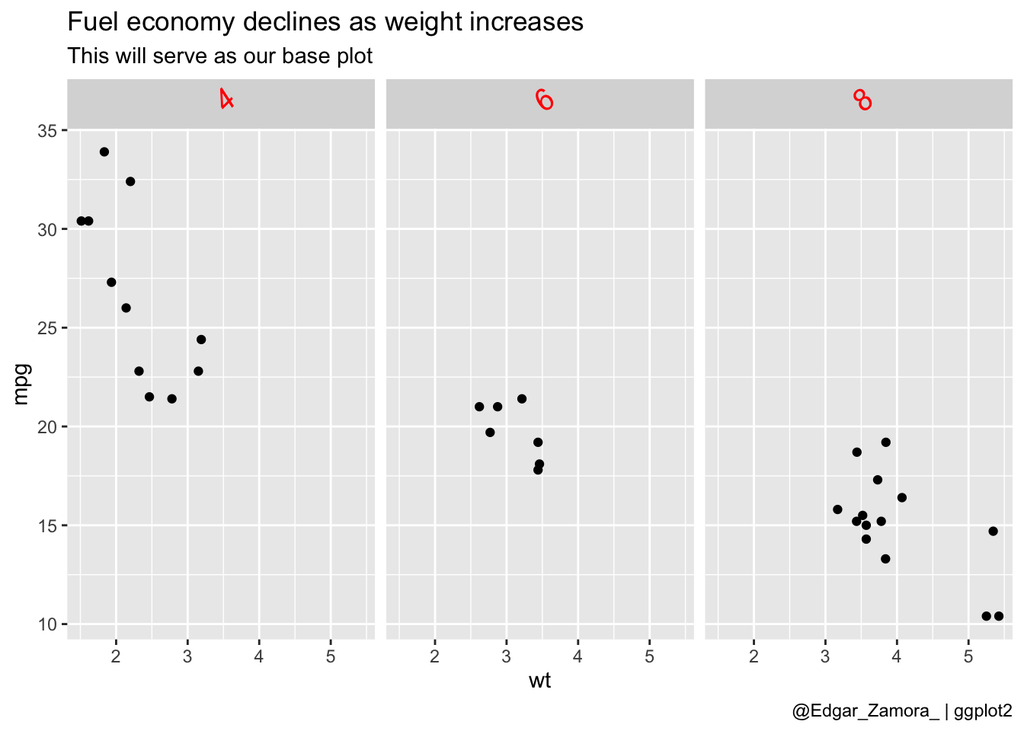

```r
base_plot +
  facet_grid(~cyl) +
  theme(strip.text = element_text(angle = 45, colour = "red", size = 15, hjust = .5, vjust = .7, face = "italic"))
```

### Text (x-axis)

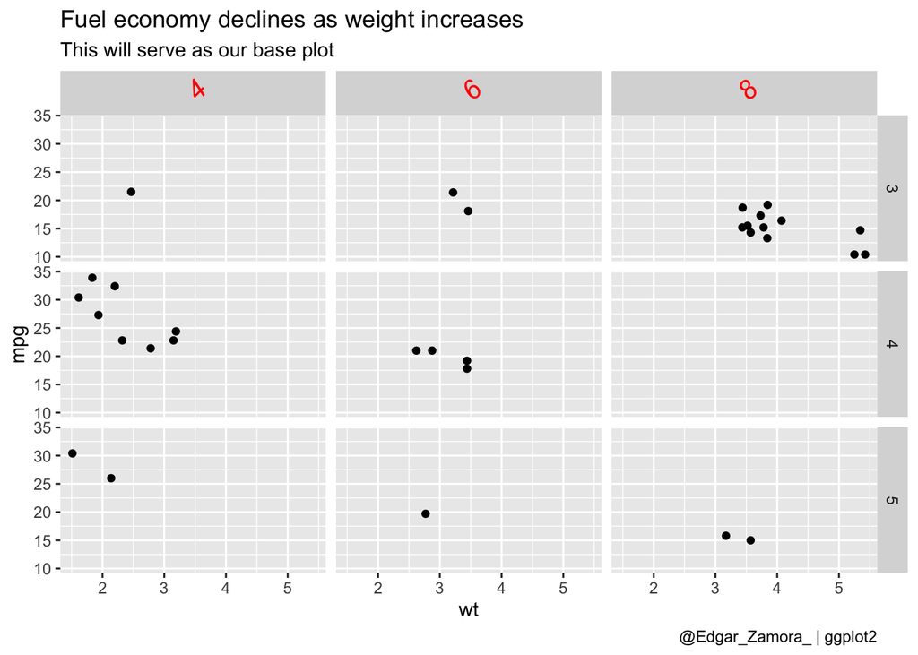

```r
base_plot +
  facet_grid(gear~cyl) +
  theme(strip.text.x = element_text(angle = 45, colour = "red", size = 15, hjust = .5, vjust = .7, face = "italic"))
```

### Text (y-axis)

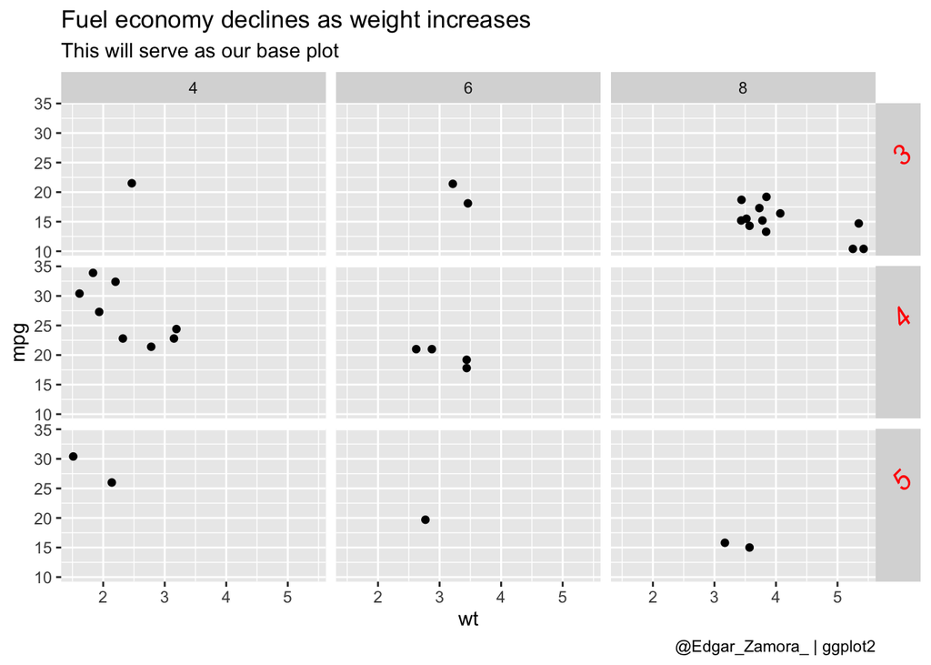

```r
base_plot +
  facet_grid(gear~cyl) +
  theme(strip.text.y = element_text(angle = 45, colour = "red", size = 15, hjust = .5, vjust = .7, face = "italic"))
```

### Switch pad grid

### Switch pad wrap

## Panel

### Background

### Border

### Spacing

### Spacing (x-axis)

### Spacing (y-axis)

### Grid

### Grid major

### Grid minor

### Grid major x-axis

### Grid major y-axis

### Grid minor x-axis

### Grid minor y-axis

### Ontop